# Day 1, Lab 2

## Lab II: Population Projections and Stability

In this section, we will project a population using the fertility, mortality and population data from the dataset from the first section of this lab. We will then compare these results to the growth rate and population structure implied by stable population theory.

We will use the same data from the earlier exercises.

First, we’ll open up the data that we used in Lab 1.

```r
d <- read_csv("bfdw_projection_data.csv") %>%
  # let's quickly repeat a few calculations that we made in Lab 1
         # change the radix to 1
  mutate(nLx = nLx/10^5,
         # make fertility rates per woman, instead of per 1000 women
         nFx = nFx/1000) %>%
  group_by(country) %>%
         # calculate the fraction of the population in each age group
  mutate(nCx = nKx/sum(nKx)) %>%
  ungroup()
```

### Leslie matrices

We need to create a Leslie matrix which contains the fertility and survivorship information in order to project a population forward. Elements in the top line of the Leslie matrix are equal to

$$_nL_0 \cdot \frac{1}{2}(_nF_x + {_nF_{x+n}}\cdot\frac{_nL_{x+n}}{_nL_x})
\cdot f_{fab}$$

and the subdiagonals are equal to

$$\frac{_nL_{x+n}}{_nL_x}.$$

Below is a function that helps to create a Leslie matrix. It takes four inputs:

- a vector of $_nL_x$ values
- a vector of $_nF_x$ values
- the number of age groups. By default this is 10, because we are considering the five year age groups from ages 0–50.
- the fraction female at birth, which is set to a default value of 0.4886.

With these inputs, the function `leslie` creates a square matrix with dimension equal to `n_age_groups` and fills in the top row and subdiagonal according to the equations above.

```r
## function to define Leslie matrix, based on nLx and nFx values
leslie <- function(nLx,
                   nFx,
                   n_age_groups=10,
                   ffab = 0.4886){
  L = matrix(0, nrow = n_age_groups, ncol = n_age_groups)
  L[1,] = ffab * nLx[1]*(nFx[1:n_age_groups]+nFx[2:(n_age_groups+1)]*nLx[2:(n_age_groups+1)]/nLx[1:n_age_groups])/2 # top row
  diag(L[2:n_age_groups,1:(n_age_groups-1)]) = nLx[2:n_age_groups] / nLx[1:(n_age_groups-1)] # subdiagonal
  return(L)
}
```

We can use this function to create a Leslie matrix using the $_nL_x$ and $_nF_x$ values for Australia:

```r
LAA <- leslie(nLx = d$nLx[d$country=="Australia"],
              nFx = d$nFx[d$country=="Australia"])
LAA
```

```
           [,1]      [,2]       [,3]       [,4]      [,5]      [,6]      [,7]      [,8]       [,9]      [,10]
 [1,] 0.0000000 0.0000000 0.01889559 0.08323168 0.1885731 0.2770073 0.2398413 0.1053085 0.01931361 0.00106925
 [2,] 0.9993985 0.0000000 0.00000000 0.00000000 0.0000000 0.0000000 0.0000000 0.0000000 0.00000000 0.00000000
 [3,] 0.0000000 0.9995963 0.00000000 0.00000000 0.0000000 0.0000000 0.0000000 0.0000000 0.00000000 0.00000000
 [4,] 0.0000000 0.0000000 0.99928252 0.00000000 0.0000000 0.0000000 0.0000000 0.0000000 0.00000000 0.00000000
 [5,] 0.0000000 0.0000000 0.00000000 0.99880073 0.0000000 0.0000000 0.0000000 0.0000000 0.00000000 0.00000000
 [6,] 0.0000000 0.0000000 0.00000000 0.00000000 0.9987295 0.0000000 0.0000000 0.0000000 0.00000000 0.00000000
 [7,] 0.0000000 0.0000000 0.00000000 0.00000000 0.0000000 0.9983661 0.0000000 0.0000000 0.00000000 0.00000000
 [8,] 0.0000000 0.0000000 0.00000000 0.00000000 0.0000000 0.0000000 0.9975890 0.0000000 0.00000000 0.00000000
 [9,] 0.0000000 0.0000000 0.00000000 0.00000000 0.0000000 0.0000000 0.0000000 0.9963091 0.00000000 0.00000000
[10,] 0.0000000 0.0000000 0.00000000 0.00000000 0.0000000 0.0000000 0.0000000 0.0000000 0.99443093 0.00000000
```

We could also use $_nL_x$ and $_nF_x$ values for any combination of the different countries, for example, $_nL_x$ values from Australia and $_nF_x$ from Senegal:

```r
LAS <- leslie(nLx = d$nLx[d$country=="Australia"],
              nFx = d$nFx[d$country=="Senegal"])
LAS
```

```
           [,1]      [,2]      [,3]      [,4]      [,5]      [,6]      [,7]      [,8]      [,9]      [,10]
 [1,] 0.0000000 0.0000000 0.1058966 0.3606475 0.5520515 0.5706600 0.4820713 0.3072678 0.1209298 0.02233855
 [2,] 0.9993985 0.0000000 0.0000000 0.0000000 0.0000000 0.0000000 0.0000000 0.0000000 0.0000000 0.00000000
 [3,] 0.0000000 0.9995963 0.0000000 0.0000000 0.0000000 0.0000000 0.0000000 0.0000000 0.0000000 0.00000000
 [4,] 0.0000000 0.0000000 0.9992825 0.0000000 0.0000000 0.0000000 0.0000000 0.0000000 0.0000000 0.00000000
 [5,] 0.0000000 0.0000000 0.0000000 0.9988007 0.0000000 0.0000000 0.0000000 0.0000000 0.0000000 0.00000000
 [6,] 0.0000000 0.0000000 0.0000000 0.0000000 0.9987295 0.0000000 0.0000000 0.0000000 0.0000000 0.00000000
 [7,] 0.0000000 0.0000000 0.0000000 0.0000000 0.0000000 0.9983661 0.0000000 0.0000000 0.0000000 0.00000000
 [8,] 0.0000000 0.0000000 0.0000000 0.0000000 0.0000000 0.0000000 0.9975890 0.0000000 0.0000000 0.00000000
 [9,] 0.0000000 0.0000000 0.0000000 0.0000000 0.0000000 0.0000000 0.0000000 0.9963091 0.0000000 0.00000000
[10,] 0.0000000 0.0000000 0.0000000 0.0000000 0.0000000 0.0000000 0.0000000 0.0000000 0.9944309 0.00000000
```

### Project the population

We can now use the Leslie matrices to project a population forward in time. Let’s start with the Australia-only Leslie matrix and project Australia’s 2015 population forward by 250 years. Note that because we are using five-year age groups, the population projection happens in five-year steps.

```r
n_age_groups <- 10 # 0-50 in 5yr age groups
n_projections <- 50 # want to project forward 50*5 = 250 years
initial_pop <- d$nKx[d$country=="Australia"] # set initial population to be Australia's population in 2015
# define population matrix K
K <- matrix(0, nrow = n_age_groups, ncol = n_projections+1)
K[,1] <- initial_pop[1:n_age_groups]

# do the projection!
for(i in 2:(n_projections+1)){
  K[,i] <- LAA%*%K[,i-1]
}

head(K[,1:5])
```

```
        [,1]     [,2]     [,3]     [,4]     [,5]
[1,] 751.868 781.6098 751.5275 708.4348 680.9857
[2,] 740.330 751.4157 781.1396 751.0754 708.0087
[3,] 688.526 740.0312 751.1124 780.8243 750.7723
[4,] 717.395 688.0320 739.5002 750.5735 780.2641
[5,] 812.546 716.5347 687.2069 738.6133 749.6734
[6,] 884.737 811.5136 715.6243 686.3338 737.6749
```

Now we have a matrix of populations by age for Australia projected into the future. We can use these numbers to investigate:

- The total population over time
- The share of the population in each age group over time
- The population growth rate over time

First, let’s get the matrix `K` in a form that’s a bit easier to plot. This involves making `K` into a dataframe in ‘long’ format, so that every row refers to a different year and age combination.

```r
# get K in a form that's easier to ggplot
# make into a dataframe, name columns as years and add an age column
Kdf <- as.data.frame(K)
colnames(Kdf) <- seq(from = 2015, to = (2015+n_projections*5), by = 5)
Kdf <- cbind(age = seq(from = 0, to = 45, by = 5), Kdf)

# get in long format and then add proportion of population in each age group
Klong <- Kdf %>%
  gather(year, population, -age) %>%
  group_by(year) %>%
  mutate(proportion = population/sum(population),
         age = as.factor(age))
head(Klong)
```

| age | year | population | proportion |
| --- | --- | --- | --- |
| 0 | 2015 | 751.868 | 0.09533330 |
| 5 | 2015 | 740.330 | 0.09387034 |
| 10 | 2015 | 688.526 | 0.08730183 |
| 15 | 2015 | 717.395 | 0.09096229 |
| 20 | 2015 | 812.546 | 0.10302698 |
| 25 | 2015 | 884.737 | 0.11218046 |

We’d like to caclulate the projected annual growth rate, $R$, of the Australian population over time.

First, let’s recall that the annual growth rate is given by the equation

$$K(t+5) = K(t) \cdot e^{5R}$$
So, solving for $R$, we have

$$R = \frac{1}{5} \cdot \log \frac{K(t+5)}{K(t)}$$
Now we’ll create a data frame that has the total population by year, and we’ll use those total population values to calculate the annual growth rate over each 5-year time step

```r
# total population by year
tot_pop <- Klong %>%
  group_by(year) %>%
  summarise(pop = sum(population)) %>%
  # this applies the formula for R that we derived above
  mutate(R = c(NA, log(pop[2:n()]/pop[1:(n()-1)])/5))
head(tot_pop)
```

| year | pop | R |
| --- | --- | --- |
| 2015 | 7886.730 | NA |
| 2020 | 7879.224 | -0.0001904453 |
| 2025 | 7761.192 | -0.0030186857 |
| 2030 | 7688.687 | -0.0018771809 |
| 2035 | 7483.595 | -0.0054073419 |
| 2040 | 7278.204 | -0.0055658533 |

OK. We have the results of our projection in nicely formatted dataframes. Let’s plot the results and see what our projection tells us.

First, let’s look at the total population over time:

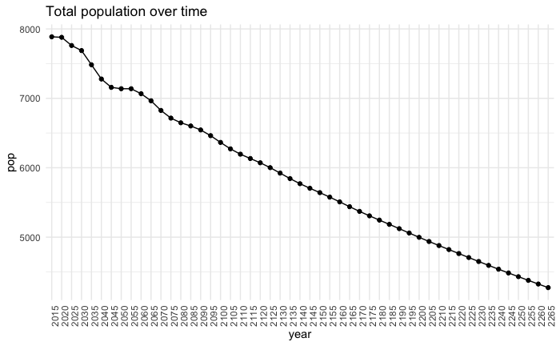

```r
# plot total population over time
ggplot(data = tot_pop, aes(x = year, y = pop, group = 1)) +
  geom_point() + geom_line()+
  theme(axis.text.x = element_text(angle = 90, hjust = 1))+
  ggtitle("Total population over time")
```

Next, let’s investigate the growth rate over time

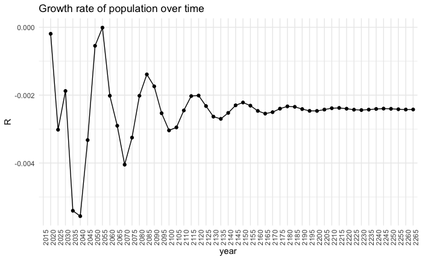

```r
# plot growth rate over time
ggplot(data = tot_pop, aes(x = year, y = R, group = 1)) +
  geom_point() + geom_line()+
  theme(axis.text.x = element_text(angle = 90, hjust = 1))+
  ggtitle("Growth rate of population over time")
```

Now we can plot total population, growth rate, and proportion in each age group over time.

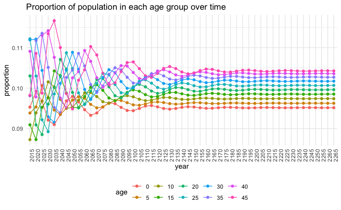

```r
# plot proportion in each age group over time
ggplot(data = Klong, aes(x = year, y = proportion, group = age, color = age)) +
  geom_point() + geom_line()+
  theme(axis.text.x = element_text(angle = 90, hjust = 1), legend.position='bottom')+
  ggtitle("Proportion of population in each age group over time")
```

```r
# summarize the code we developed above in a function
project_population <- function(n_age_groups = 10,
                               n_projections = 50,
                               # the starting population
                               initial_pop,
                               # the Leslie matrix
                               L) {

  # define population matrix K
  K <- matrix(0, nrow = n_age_groups, ncol = n_projections+1)
  K[,1] <- initial_pop[1:n_age_groups]

  # do the projection!
  for(i in 2:(n_projections+1)){
    K[,i] <- L%*%K[,i-1]
  }

  # get K in a form that's easier to ggplot
  # make into a dataframe, name columns as years and add an age column
  Kdf <- as.data.frame(K)
  colnames(Kdf) <- seq(from = 2015, to = (2015+n_projections*5), by = 5)
  Kdf <- cbind(age = seq(from = 0, to = 45, by = 5), Kdf)

  # get in long format and then add proportion of population in each age group
  Klong <- Kdf %>%
    gather(year, population, -age) %>%
    group_by(year) %>%
    mutate(proportion = population/sum(population),
           age = as.factor(age))

  # summarize the projection with total population and growth rate
  tot_pop <- Klong %>%
    group_by(year) %>%
    summarise(pop = sum(population)) %>%
    # this applies the formula for R that we derived above
    mutate(R = c(NA, log(pop[2:n()]/pop[1:(n()-1)])/5))

  return(list(projection = Klong,
              tot_pop = tot_pop))
}
```

Let’s illustrate how this function works by quickly repeating the projection we made for Australia. We feed Australia’s starting values and Australia’s Leslie matrix into the function, and the result is an list with two objects: `projection` and `tot_pop`.

```r
proj_AA <- project_population(initial_pop = d$nKx[d$country == 'Australia'],
                              L =  LAA)

names(proj_AA)
```

```
[1] "projection" "tot_pop"
```

`projection` has the long-form projection results, with the projected number of women in each age group at each time period:

```r
proj_AA$projection
```

| age | year | population | proportion |
| --- | --- | --- | --- |
| 0 | 2015 | 751.8680 | 0.09533330 |
| 5 | 2015 | 740.3300 | 0.09387034 |
| 10 | 2015 | 688.5260 | 0.08730183 |
| 15 | 2015 | 717.3950 | 0.09096229 |
| 20 | 2015 | 812.5460 | 0.10302698 |
| 25 | 2015 | 884.7370 | 0.11218046 |
| 30 | 2015 | 882.4950 | 0.11189619 |
| 35 | 2015 | 773.7630 | 0.09810948 |
| 40 | 2015 | 860.3120 | 0.10908349 |
| 45 | 2015 | 774.7580 | 0.09823564 |

[output cut: 500 more lines]

and `tot_pop` summarizes the projection with total population size and growth rate:

```r
proj_AA$tot_pop
```

| year | pop | R |
| --- | --- | --- |
| 2015 | 7886.730 | NA |
| 2020 | 7879.224 | -1.904453e-04 |
| 2025 | 7761.192 | -3.018686e-03 |
| 2030 | 7688.687 | -1.877181e-03 |
| 2035 | 7483.595 | -5.407342e-03 |
| 2040 | 7278.204 | -5.565853e-03 |
| 2045 | 7158.247 | -3.323777e-03 |
| 2050 | 7138.728 | -5.461279e-04 |
| 2055 | 7138.360 | -1.030208e-05 |
| 2060 | 7066.701 | -2.017869e-03 |

[output cut: 41 more lines]

## Exercises

> **Q1a**. Pick another country and project the population forward 50 time steps, like we just did for Australia. Copy/adapt the code above to make a plot of the trajectory of the total population size, growth rate and the age distributions for your projection.

> **Q1b**. In lecture, we looked at an expression for the number of people in each age group of a stable population with growth rate $r$. We said $_nK_x(t) = B(t) e^{-rx} _nL_x/l_0$. See if you can convert this into an expression for the fraction of the population in each age group of a stable population, which we call $_nc_x$.

> **Q1c**. See if you can estimate the intrinsic growth rate $r$ in the stable population by comparing the size of age groups in your projection. (NB: there is more than one way to do this.)

> **Q2a**. Now find a third country, and use the Leslie matrix from the country you picked for (1) to project the population of the country from (1) forward for 50 time steps, but assume that the starting population is the population of the third country. Does this population converge to the same size? The same growth rate? The same age structure?

> **Q2b**. Look at the trajectory of the growth rate in the projection from Q1 and the projection from Q2a. Which projection took longer to converge to stability? What do you think might affect the amount of time it takes to converge to stability? If you have time, you can check some of your predictions by making projections using other combinations of Leslie matrices and starting values.